# MAPA Functions

Ishaan Gadiyar

2026-04-14

# 1 Introduction

The aim of this tutorial is to show users how to download the *MAPA* package and how to appropriately use the functions available in the package. While this specific tutorial uses the *Reproducible Brain Charts (RBC)* dataset (https://reprobrainchart.github.io/) to train and evaluate random forest and ridge regression models, *MAPA* can be used across a variety of black-box models that predict continuous outcomes.

# 2 Loading Packages/Libraries

```r
library(tidyverse)
library(knitr)
library(glmnet)
library(locfit)
library(ggplot2)
library(ranger)
library(tuneRanger)
library(mlr)

# Installing and loading MAPA package
if (!"MAPA" %in% rownames(installed.packages())) {
  devtools::install_github("statimagcoll/MAPA")
}
library(MAPA)

# Setting the seed
set.seed(123)
```

# 3 Installing Data

Here, we utilize data from the *Reproducible Brain Charts (RBC)* data set, accessible via the *datalad* package in R (https://reprobrainchart.github.io/docs/get_data). More specifically, this tutorial will use data from the *PNC1* study site within the RBC data set, a subset of data taken from the *RBC* data set.

In *pnc_data*, the pertinent data that we use are:

- Age: a continuous measure in years that represents how old a subject’s brain is. We predict this measure in both model examples.
- 17Networks: columns that contain ‘17Networks’ represent structural brain measures, or variables that give a measure of the volume of specific regions within the brain.
- *to*: columns that contain ‘*to*’ represent functional brain measures, or variables that give a measure of brain activity within specicif regions of the brain.
- sex_bin: represents the sex of the subject, where 1 represents a male and 0 represents a female.
- euler: represents the Euler number, which is used to assess the quality of structural MRI scans.
- meanFD: represents the mean frame displacment rate, which is used to assess the quality of function MRI scans.

Please note that data is unharmonized and depending on the method of download/processing, column names may vary within the RBC data.

```r
# Loading in the structural data - denoted by column names with '17Networks'
rbc <- read_csv("/media/disk2/RBC_version0.1/regional_GMV_all_sites_unharmonized.csv")
```

```
## ──────────────────────────────────────────────────────── Delimiter: "," chr
## (13): participant_id, session_id, study, study_site, wave, sex, race, e... dbl
## (377): ...1, age, bmi, p_factor_mcelroy_harmonized_all_samples, internal...
```

```r
# Loading in the functional data - denoted by column names with '_to_'
func <- read_csv("/media/disk2/RBC_version0.1/FC_network17_unharmonized.csv")
```

```
## ──────────────────────────────────────────────────────── Delimiter: "," chr
## (19): ...1, participant_id, session_id, study, study_site, wave, sex, r... dbl
## (181): age, bmi, p_factor_mcelroy_harmonized_all_samples, internalizing_...
```

```r
# Setting each dataset to only include patients that overlap
rbc = rbc[rbc$participant_id %in% func$participant_id,]
func = func[func$participant_id %in% rbc$participant_id,]

# Checking that only overlapping participants exist
sum(rbc$participant_id == func$participant_id) == nrow(func)
```

```
## [1] TRUE
```

```r
# Merging datasets
cols_to_add <- setdiff(names(func), names(rbc))
total_data <- cbind(rbc, func[cols_to_add])

# Subsetting study site to HBNsiteSI
pnc_data = total_data %>% filter(study_site == "PNC1")

# Turning the sex column into a binary stored in 'sex_bin'
pnc_data <- pnc_data %>%
  mutate(sex_bin = ifelse(pnc_data$sex == "Male", 1, 0))
```

# 4 Ridge Regression Model Examples

This section seeks to highlight how the *MAPA* package can be used to evaluate ridge regression models in two instances where 1) a model is only trained on cross-fold validation or 2) a model is trained with cross-fold validation and sample splits.

## 4.1 Ridge Regression Example with only Cross-Fold Validation

### 4.1.1 Training the Model

Here, we test how the inclusion of either structural or functional MRI data in a ridge regression model impacts model accuracy when predicting age.

```r
# Cleaning data - drop NA before cross-fold validation
data_clean = pnc_data %>% drop_na(age)

# Instantiating number of folds and assigning fold number randomly
folds = 5
data_clean$fold <- sample(rep(1:folds, length.out = nrow(data_clean)))

# Sanity check for fold distribution
table(data_clean$fold)
```

```
##
##   1   2   3   4   5
## 246 246 245 245 245
```

```r
# Creating storage variables for lambda (a finetuning variable)
lambda_struct = c()
lambda_func = c()

# Creating storage columns for model predictions
data_clean$preds_struct = NA
data_clean$preds_func = NA

# Creating a for loop for 5-fold cross validation
for(i in 1:folds){
  # Assigning data
  test = data_clean %>% filter(fold == i)
  train = data_clean %>% filter(fold != i)

  # Creating model data variables for training
  x_var_struct = as.matrix(train[, grepl('17Networks', colnames(train)) | colnames(train) %in% c("sex_bin", "euler", "meanFD")])
  y_var = as.matrix(train[, colnames(train) %in% c("age")])
  x_var_func = as.matrix(train[, grepl('_to_', colnames(train)) | colnames(train) %in% c("sex_bin", "euler", "meanFD")])

  # Creating model variables for prediction
  newx_struct = as.matrix(test[, grepl('17Networks', colnames(test)) | colnames(test) %in% c("sex_bin", "euler", "meanFD")])
  newx_func = as.matrix(test[, grepl('_to_', colnames(test)) | colnames(test) %in% c("sex_bin", "euler", "meanFD")])
  newy = as.matrix(test[, colnames(test) %in% c("age")])

  # Fitting a ridge regression model
  lambda_seq <- c(
    seq(10, 1, -1),        # From 10 to 1 (step of 1)
    seq(0.9, 0.1, -0.1),   # From 0.9 to 0.1 (step of 0.1)
    seq(0.09, 0.01, -0.01),# From 0.09 to 0.01 (step of 0.01)
    seq(0.009, 0.001, -0.001), # From 0.009 to 0.001 (step of 0.001)
    seq(0.0009, 0.0001, -0.0001), # From 0.0009 to 0.0001 (step of 0.0001)
    seq(0.00009, 0.00001, -0.00001), # From 0.00009 to 0.00001
    seq(0.000009, 0.000001, -0.000001), # From 0.000009 to 0.000001
    seq(0.0000009, 0.0000001, -0.0000001), # From 0.0000009 to 0.0000001
    0
  )

  # Training respective models
  ridgeModel_struct <- cv.glmnet(x_var_struct, y_var, alpha = 0, lambda = lambda_seq)
  ridgeModel_func <- cv.glmnet(x_var_func, y_var, alpha = 0, lambda = lambda_seq)

  # Getting predictions
  test$preds_struct = predict(ridgeModel_struct, newx = newx_struct, s = "lambda.min")[,]
  test$preds_func = predict(ridgeModel_func, newx = newx_func, s = "lambda.min")[,]

  # Storing prediction values
  ## Isolating to a singular data frame with only the prediction values and IDs
  test_collapsed <- test %>%
  group_by(participant_id) %>%
  summarise(
    preds_struct = first(na.omit(preds_struct)),
    preds_func = first(na.omit(preds_func)),
    .groups = "drop"
  )

  ## Matching the predictions by ID to the original data frame
  data_clean <- data_clean %>%
  left_join(test_collapsed, by = "participant_id", suffix = c("", "_new"))%>%
  mutate(
    preds_struct = ifelse(is.na(preds_struct_new), preds_struct, preds_struct_new),
    preds_func = ifelse(is.na(preds_func_new), preds_func, preds_func_new)
  ) %>%
  select(-ends_with("_new"))


  # Storing minimum lambda used for each ridge regression model
  lambda_struct = c(lambda_struct, ridgeModel_struct$lambda.min)
  lambda_func = c(lambda_func, ridgeModel_func$lambda.min)
}
```

### 4.1.2 Applying mapa to Data Predictions

```r
# Gathering the estimates with one sample split
results = mapa(as.matrix(data_clean$age), as.matrix(data_clean$preds_struct), as.matrix(data_clean$fold), as.matrix(data_clean$preds_func))

# Here, yhat1 represents the prediction accuracy of the structural model and
# yhat2 represents the prediction accuracy of the functional model
results$est <- results$est %>% mutate(metric = recode(metric, yhat1 = "Structural Data", yhat2 = "Functional Data"))
results$est_summary <- results$est_summary %>% mutate(metric = recode(metric, yhat1 = "Structural Data", yhat2 = "Functional Data"))

# Previewing summarized results
results$est_summary
```

```
##            metric          scale        est         se         LB         UB
## 1      Difference          r2-r1  0.2129679 0.01841812  0.1768691  0.2490668
## 2           Ratio log(f2^2/f1^2)  1.1766783 0.09934370  0.9819682  1.3713884
## 3 Structural Data     logit(r^2)  0.3863134 0.07532461  0.2386799  0.5339469
## 4 Functional Data     logit(r^2) -0.7903649 0.10414541 -0.9944861 -0.5862436
## 5 Structural Data              r  0.7716184         NA  0.7479227  0.7939793
## 6 Functional Data              r  0.5586505         NA  0.5196411  0.5979107
```

```r
head(results$est)
```

```
##            metric          scale        est         se split
## 1 Structural Data     logit(r^2)  0.3863134 0.07532461     1
## 2 Functional Data     logit(r^2) -0.7903649 0.10414541     1
## 3      Difference          r2-r1  0.2129679 0.01841812     1
## 4           Ratio log(f2^2/f1^2)  1.1766783 0.09934370     1
```

### 4.1.3 Graphing Outputs

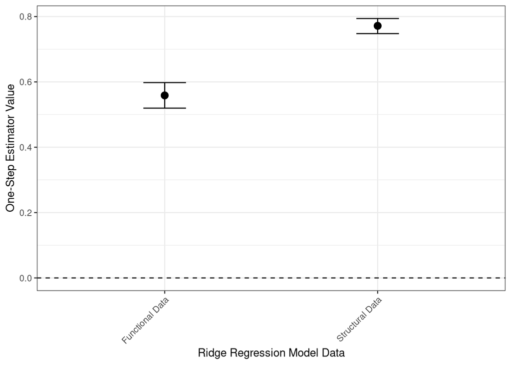

```r
# Subsetting results to only estimates
toPlot = results$est_summary %>% filter((metric == "Structural Data" | metric == "Functional Data") & scale == "r")
toPlot_Diff = results$est_summary %>% filter(metric == "Difference")

# Plotting one-step results
ggplot(toPlot, aes(x = metric, y = est)) +
  geom_point(position = position_dodge(width = 0.5), size = 3) +
  geom_errorbar(aes(ymin = LB, ymax = UB),
                width = 0.2,
                position = position_dodge(width = 0.5)) +
  theme_bw() +
  theme(axis.text.x = element_text(angle = 45, hjust=1)) +
  geom_hline(yintercept = 0, linetype = "dashed", color = "black")  +
  labs(x = "Ridge Regression Model Data", y = "One-Step Estimator Value")
```

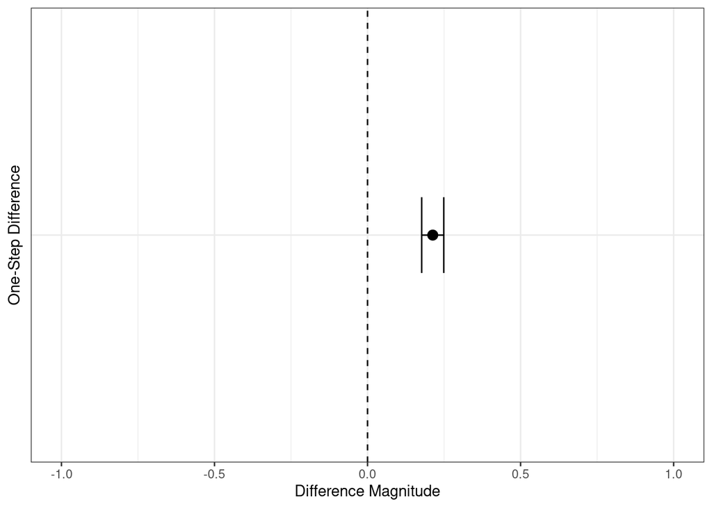

```r
# Plotting one-step difference results
ggplot(toPlot_Diff, aes(x = metric, y = est)) +
  geom_point(position = position_dodge(width = 0.5), size = 3) +
  geom_errorbar(aes(ymin = LB, ymax = UB),
                width = 0.2,
                position = position_dodge(width = 0.5)) +
  theme_bw() +
  theme(axis.ticks.y = element_blank(), axis.text.y = element_blank()) +
  coord_flip() +
  geom_hline(yintercept = 0, linetype = "dashed", color = "black")  +
  ylim(-1,1) +
  labs(x = "One-Step Difference", y = "Difference Magnitude")
```

### 4.1.4 Analysis

Here, we see that the ridge regression model trained with structural MRI data performs significantly better than the model trained with functional MRI data when predicting the continuous variable age.

## 4.2 Ridge Regression Example with Sample Splits

### 4.2.1 Training the Model

Here, like section 4.1, we test how the inclusion of either structural or functional MRI data in a ridge regression model impacts model accuracy when predicting age. However, this time we incorporate sample splits.

```r
# Cleaning data
data_clean = pnc_data %>% drop_na(age)

# Assigning sample split number and fold number
ss_num = 20
folds = 5

# Creating storage variables for hypertuning
lambda_struct = c()
lambda_func = c()

# Assigning storage matrices within data frame columns
data_clean$struct_ss  <- matrix(nrow = nrow(data_clean), ncol = 0)
data_clean$func_ss  <- matrix(nrow = nrow(data_clean), ncol = 0)
data_clean$fold_ss  <- matrix(nrow = nrow(data_clean), ncol = 0)


for(j in 1:ss_num){
  # Creating a temporary data frame
  data_temp <- data_clean

  # Creating storage columns
  data_temp$preds_struct = NA
  data_temp$preds_func = NA

  # Randomly assigning fold numbers within the temporary data frame
  data_temp$fold <- sample(rep(1:folds, length.out = nrow(data_temp)))

  # Creating a for loop for 5-fold cross validation
  for(i in 1:folds){
    # Assigning data
    test = data_temp %>% filter(fold == i)
    train = data_temp %>% filter(fold != i)

    # Creating model data variables for training
    x_var_struct = as.matrix(train[, grepl('17Networks', colnames(train)) | colnames(train) %in% c("sex_bin", "euler", "meanFD")])
    y_var = as.matrix(train[, colnames(train) %in% c("age")])
    x_var_func = as.matrix(train[, grepl('_to_', colnames(train)) | colnames(train) %in% c("sex_bin", "euler", "meanFD")])

    # Creating model variables for prediction
    newx_struct = as.matrix(test[, grepl('17Networks', colnames(test)) | colnames(test) %in% c("sex_bin", "euler", "meanFD")])
    newx_func = as.matrix(test[, grepl('_to_', colnames(test)) | colnames(test) %in% c("sex_bin", "euler", "meanFD")])
    newy = as.matrix(test[, colnames(test) %in% c("age")])

    # Fitting a ridge regression model
    lambda_seq <- c(
      seq(10, 1, -1),        # From 10 to 1 (step of 1)
      seq(0.9, 0.1, -0.1),   # From 0.9 to 0.1 (step of 0.1)
      seq(0.09, 0.01, -0.01),# From 0.09 to 0.01 (step of 0.01)
      seq(0.009, 0.001, -0.001), # From 0.009 to 0.001 (step of 0.001)
      seq(0.0009, 0.0001, -0.0001), # From 0.0009 to 0.0001 (step of 0.0001)
      seq(0.00009, 0.00001, -0.00001), # From 0.00009 to 0.00001
      seq(0.000009, 0.000001, -0.000001), # From 0.000009 to 0.000001
      seq(0.0000009, 0.0000001, -0.0000001), # From 0.0000009 to 0.0000001
      0
    )

    # Training respective models
    ridgeModel_struct <- cv.glmnet(x_var_struct, y_var, alpha = 0, lambda = lambda_seq)
    ridgeModel_func <- cv.glmnet(x_var_func, y_var, alpha = 0, lambda = lambda_seq)

    # Getting predictions
    test$preds_struct = predict(ridgeModel_struct, newx = newx_struct, s = "lambda.min")[,]
    test$preds_func = predict(ridgeModel_func, newx = newx_func, s = "lambda.min")[,]

    # Storing prediction values
    ## Isolating to a singular data frame with only the prediction values and IDs
    test_collapsed <- test %>%
      group_by(participant_id) %>%
      summarise(
        preds_struct = first(na.omit(preds_struct)),
        preds_func = first(na.omit(preds_func)),
        .groups = "drop"
      )

    ## Matching the predictions by ID to the original data frame
    data_temp <- data_temp %>%
      left_join(test_collapsed, by = "participant_id", suffix = c("", "_new"))%>%
      mutate(
        preds_struct = ifelse(is.na(preds_struct_new), preds_struct, preds_struct_new),
        preds_func = ifelse(is.na(preds_func_new), preds_func, preds_func_new)
      ) %>%
      select(-ends_with("_new"))


    # Storing minimum lambda used for each ridge regression model
    lambda_struct = c(lambda_struct, ridgeModel_struct$lambda.min)
    lambda_func = c(lambda_func, ridgeModel_func$lambda.min)
  }

  # Storing results from each model
  data_clean$struct_ss <- cbind(data_clean$struct_ss, as.matrix(data_temp$preds_struct))
  data_clean$func_ss <- cbind(data_clean$func_ss, as.matrix(data_temp$preds_func))
  data_clean$fold_ss <- cbind(data_clean$fold_ss, as.matrix(data_temp$fold))
}
```

### 4.2.2 Applying mapa to Data Predictions

```r
# Gathering the estimates with four sample splits
results = mapa(data_clean$age, data_clean$struct_ss, data_clean$fold_ss, data_clean$func_ss)

# Here, yhat1 represents the prediction accuracy of the structural model and
# yhat2 represents the prediction accuracy of the functional model
results$est <- results$est %>% mutate(metric = recode(metric, yhat1 = "Structural Data", yhat2 = "Functional Data"))
results$est_summary <- results$est_summary %>% mutate(metric = recode(metric, yhat1 = "Structural Data", yhat2 = "Functional Data"))

# Previewing summarized results
results$est_summary
```

```
##            metric          scale        est         se          LB         UB
## 1      Difference          r2-r1  0.1850221 0.01888047  0.14801708  0.2220272
## 2           Ratio log(f2^2/f1^2)  0.9960877 0.10169244  0.79677417  1.1954012
## 3 Structural Data     logit(r^2)  0.1348135 0.07801714 -0.01809728  0.2877243
## 4 Functional Data     logit(r^2) -0.8544002 0.10245014 -1.05519879 -0.6536016
## 5 Structural Data              r  0.7305152         NA  0.70390042  0.7559358
## 6 Functional Data              r  0.5463613         NA  0.50816143  0.5849602
```

```r
head(results$est)
```

```
##            metric          scale         est         se split
## 1 Structural Data     logit(r^2)  0.13182002 0.07764369     1
## 2 Functional Data     logit(r^2) -0.87916047 0.10153886     1
## 3      Difference          r2-r1  0.18838546 0.01888245     1
## 4           Ratio log(f2^2/f1^2)  1.01098049 0.10160417     1
## 5 Structural Data     logit(r^2)  0.08179834 0.08307127     2
## 6 Functional Data     logit(r^2) -0.84773350 0.10090062     2
```

### 4.2.3 Graphing Outputs

Here, we take the median of the estimate and bound values from each sample split to determine what one-step estimator, lower-bound, and upper-bound value to plot.

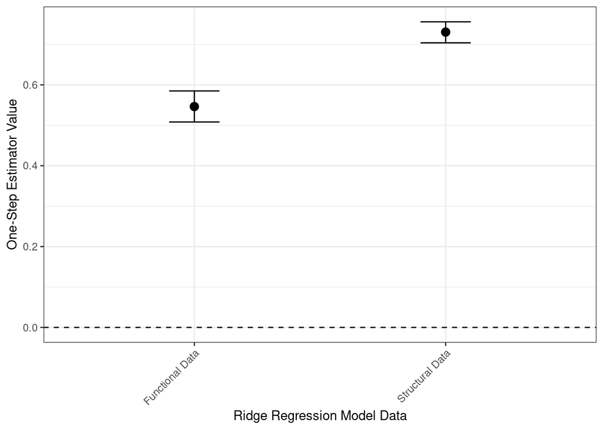

```r
# Filtering to only the estimates for the structural and functional estimates
toPlot <- results$est_summary %>% filter((metric == "Structural Data" | metric == "Functional Data") & scale == "r")
toPlot_Diff <- results$est_summary %>% filter(metric == "Difference")

# Plotting results
ggplot(toPlot, aes(x = metric, y = est)) +
  geom_point(position = position_dodge(width = 0.5), size = 3) +
  geom_errorbar(aes(ymin = LB, ymax = UB),
                width = 0.2,
                position = position_dodge(width = 0.5)) +
  theme_bw() +
  theme(axis.text.x = element_text(angle = 45, hjust=1)) +
  geom_hline(yintercept = 0, linetype = "dashed", color = "black")  +
  labs(x = "Ridge Regression Model Data", y = "One-Step Estimator Value")
```

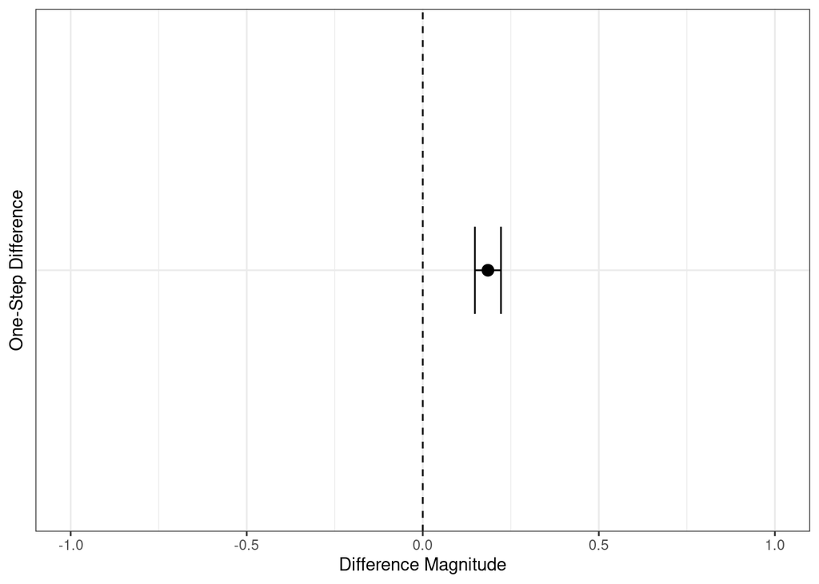

```r
# Plotting one-step difference results
ggplot(toPlot_Diff, aes(x = metric, y = est)) +
  geom_point(position = position_dodge(width = 0.5), size = 3) +
  geom_errorbar(aes(ymin = LB, ymax = UB),
                width = 0.2,
                position = position_dodge(width = 0.5)) +
  theme_bw() +
  theme(axis.ticks.y = element_blank(), axis.text.y = element_blank()) +
  coord_flip() +
  geom_hline(yintercept = 0, linetype = "dashed", color = "black")  +
  ylim(-1,1) +
  labs(x = "One-Step Difference", y = "Difference Magnitude")
```

### 4.2.4 Analysis

Here, even with the inclusion of sample splits to test other scenarios where fold assignment randomly differs, we still see that the model trained on structural data performs significantly better than the model trained on functional data when predicting subject age.

# 5 Random Forest Model Examples

This section seeks to highlight how the *MAPA* package can be used to evaluate random forest models in two instances where 1) a model is only trained on cross-fold validation or 2) a model is trained with cross-fold validation and sample splits.

## 5.1 Methods

Here, outside of the random forest model package itself, we create the *helper_ranger* function to help tune and check the validity of our model tuning.

```r
# tuning function
helper_ranger = function(trainDat, outcome, testDat, task){
  # If the tuned model already gives non-constant preds, keep it.
  if (sd(predict(task$model, newdata = data.frame(testDat))$data$response) > 1e-5) {
    return(task$model)
  }

  # Otherwise walk the tried hyperparams (best MSE first) and re-train via mlr
  tune_table <- task$results[order(task$results$mse), ]

  for (i in seq_len(nrow(tune_table))) {
    params <- tune_table[i, ]

    # build an mlr learner with these params
    lrn <- mlr::makeLearner(
      "regr.ranger",
      num.trees       = 250,
      mtry            = params$mtry,
      min.node.size   = params$min.node.size,
      sample.fraction = params$sample.fraction,
      num.threads     = 1,
      respect.unordered.factors = "order"  # or as needed
    )

    # train an mlr model so predict() keeps the same API
    tr_task <- mlr::makeRegrTask(id = "rf_task_retry", data = trainDat, target = outcome)
    wm <- mlr::train(lrn, tr_task)

    # check for non-constant predictions
    if (sd(predict(wm, newdata = data.frame(testDat))$data$response) > 1e-5) {
      return(wm)
    }
  }

  # if everything fails, just return the original
  return(task$model)
}
```

## 5.2 Random Forest Example with only Cross-Fold Validation

### 5.2.1 Training the Model

Here, we test how the inclusion of either structural or functional data in a random forest model impacts model accuracy when predicting age.

```r
# Cleaning data - drop NA before CV
data_clean = pnc_data %>% drop_na(age)

# Assigning folds randomly
folds = 5
data_clean$fold <- sample(rep(1:folds, length.out = nrow(data_clean)))

# Selecting an outcome variable
outcome = "age"

# Sanity check for fold distribution
table(data_clean$fold)
```

```
##
##   1   2   3   4   5
## 246 246 245 245 245
```

```r
# Creating storage columns
data_clean$preds_struct = NA
data_clean$preds_func = NA

# Creating a for loop for 5-fold cross validation
for(i in 1:folds){
  # Assigning data
  test = data_clean %>% filter(fold == i)
  train = data_clean %>% filter(fold != i)

  # Creating model data variables for training
  x_var_struct = data.frame(train[, grepl('17Networks', colnames(train)) | colnames(train) %in% c(outcome, "sex_bin", "euler", "meanFD")])
  y_var = data.frame(train[, colnames(train) %in% c("age")])
  x_var_func = data.frame(train[, grepl('_to_', colnames(train)) | colnames(train) %in% c(outcome, "sex_bin", "euler", "meanFD")])

  # Creating model variables for prediction
  newx_struct = data.frame(test[, grepl('17Networks', colnames(test)) | colnames(test) %in% c("sex_bin", "euler", "meanFD")])
  newx_func = data.frame(test[, grepl('_to_', colnames(test)) | colnames(test) %in% c("sex_bin", "euler", "meanFD")])
  newy = data.frame(test[, colnames(test) %in% c("age")])

  # Creating random forest tasks
  task_struct = makeRegrTask(id = "rf_task", data = x_var_struct, target = outcome)
  task_func = makeRegrTask(id = "rf_task", data = x_var_func, target = outcome)

  # Tuning each model
  rfTune_struct = tuneRanger(task_struct, num.trees = 250, iters = 25, iters.warmup = 10, show.info = FALSE)
  rfTune_func = tuneRanger(task_func, num.trees = 250, iters = 25, iters.warmup = 10, show.info = FALSE)

  # Checking the tuning of each model
  rfTune_struct$model = helper_ranger(x_var_struct, outcome, newx_struct, rfTune_struct) # Calling for checking of tuning
  rfTune_func$model = helper_ranger(x_var_func, outcome, newx_func, rfTune_func) # Calling for checking of tuning

  # Getting predictions
  test$preds_struct = predict(rfTune_struct$model, newdata = newx_struct)$data$response
  test$preds_func = predict(rfTune_func$model, newdata = newx_func)$data$response

  # Storing prediction values
  ## Isolating to a singular data frame with only the prediction values and IDs
  test_collapsed <- test %>%
  group_by(participant_id) %>%
  summarise(
    preds_struct = first(na.omit(preds_struct)),
    preds_func= first(na.omit(preds_func)),
    .groups = "drop"
  )

  ## Matching the predictions by ID to the original data frame
  data_clean <- data_clean %>%
  left_join(test_collapsed, by = "participant_id", suffix = c("", "_new"))%>%
  mutate(
    preds_struct = ifelse(is.na(preds_struct_new), preds_struct, preds_struct_new),
    preds_func = ifelse(is.na(preds_func_new), preds_func, preds_func_new)
  ) %>%
  select(-ends_with("_new"))
}
```

### 5.2.2 Applying mapa to Data Predictions

```r
# Gathering the estimates with one sample split
results = mapa(as.matrix(data_clean$age), as.matrix(data_clean$preds_struct), as.matrix(data_clean$fold), as.matrix(data_clean$preds_func))

# Here, yhat1 represents the prediction accuracy of the structural model and
# yhat2 represents the prediction accuracy of the functional model
results$est <- results$est %>% mutate(metric = recode(metric, yhat1 = "Structural Data", yhat2 = "Functional Data"))
results$est_summary <- results$est_summary %>% mutate(metric = recode(metric, yhat1 = "Structural Data", yhat2 = "Functional Data"))

# Previewing summarized results
results$est_summary
```

```
##            metric          scale        est         se          LB         UB
## 1      Difference          r2-r1  0.1781858 0.02322835  0.13265912  0.2237126
## 2           Ratio log(f2^2/f1^2)  0.9689831 0.12336778  0.72718674  1.2107795
## 3 Structural Data     logit(r^2)  0.2216065 0.10407499  0.01762323  0.4255897
## 4 Functional Data     logit(r^2) -0.7473767 0.14123877 -1.02419958 -0.4705538
## 5 Structural Data              r  0.7451013         NA  0.71021524  0.7777018
## 6 Functional Data              r  0.5669155         NA  0.51401380  0.6200687
```

```r
head(results$est)
```

```
##            metric          scale        est         se split
## 1 Structural Data     logit(r^2)  0.2216065 0.10407499     1
## 2 Functional Data     logit(r^2) -0.7473767 0.14123877     1
## 3      Difference          r2-r1  0.1781858 0.02322835     1
## 4           Ratio log(f2^2/f1^2)  0.9689831 0.12336778     1
```

### 5.2.3 Graphing Outputs

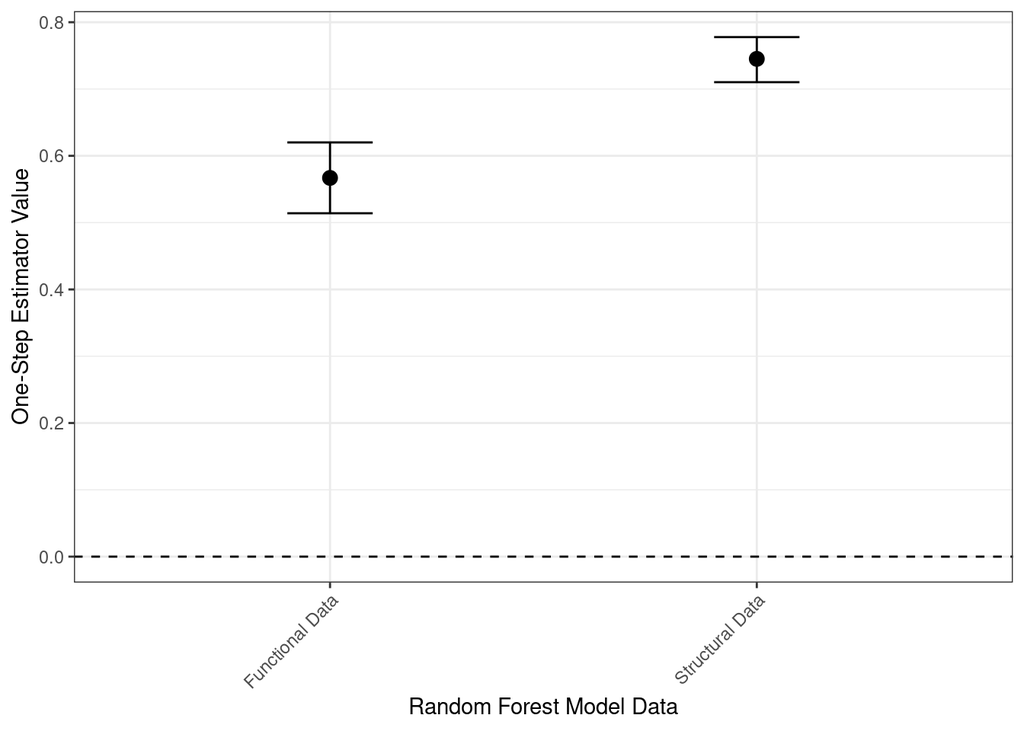

```r
# Subsetting results to only estimates
toPlot = results$est_summary %>% filter((metric == "Structural Data" | metric == "Functional Data") & scale == "r")
toPlot_Diff =  results$est_summary %>% filter(metric == "Difference")

# Plotting one-step results
ggplot(toPlot, aes(x = metric, y = est)) +
  geom_point(position = position_dodge(width = 0.5), size = 3) +
  geom_errorbar(aes(ymin = LB, ymax = UB),
                width = 0.2,
                position = position_dodge(width = 0.5)) +
  theme_bw() +
  theme(axis.text.x = element_text(angle = 45, hjust=1)) +
  geom_hline(yintercept = 0, linetype = "dashed", color = "black")  +
  labs(x = "Random Forest Model Data", y = "One-Step Estimator Value")
```

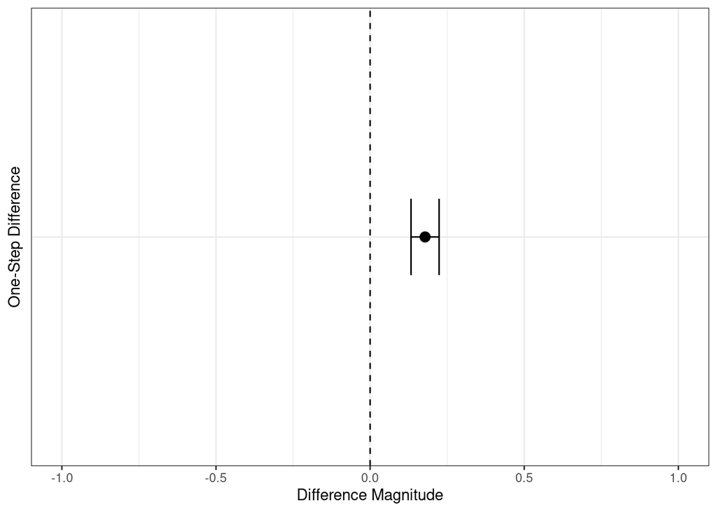

```r
# Plotting one-step difference results
ggplot(toPlot_Diff, aes(x = metric, y = est)) +
  geom_point(position = position_dodge(width = 0.5), size = 3) +
  geom_errorbar(aes(ymin = LB, ymax = UB),
                width = 0.2,
                position = position_dodge(width = 0.5)) +
  theme_bw() +
  theme(axis.ticks.y = element_blank(), axis.text.y = element_blank()) +
  coord_flip() +
  geom_hline(yintercept = 0, linetype = "dashed", color = "black")  +
  ylim(-1,1) +
  labs(x = "One-Step Difference", y = "Difference Magnitude")
```

### 5.2.4 Analysis

Here, we see that the model trained on structural data performs significantly better than the model trained on functional data when predicting subject age.

## 5.3 Random Forest Example with Sample Splits

### 5.3.1 Training the Model

```r
# Cleaning data
data_clean = pnc_data %>% drop_na(age)

# Assigning sample split number and fold number
ss_num = 20
folds = 5

# Creating storage variables for hypertuning
lambda_struct = c()
lambda_func = c()

# Assigning storage matrices within data frame columns
data_clean$struct_ss  <- matrix(nrow = nrow(data_clean), ncol = 0)
data_clean$func_ss  <- matrix(nrow = nrow(data_clean), ncol = 0)
data_clean$fold_ss  <- matrix(nrow = nrow(data_clean), ncol = 0)

# Running the sample splits
for(j in 1:ss_num){
  # Creating a temporary data frame
  data_temp <- data_clean

  # Creating storage columns
  data_temp$preds_struct = NA
  data_temp$preds_func = NA

  # Setting fold numbers for temporary data frame
  data_temp$fold <- sample(rep(1:folds, length.out = nrow(data_temp)))


  # Creating a for loop for 5-fold cross validation
  for(i in 1:folds){
    # Assigning data
    test = data_temp %>% filter(fold == i)
    train = data_temp %>% filter(fold != i)

    # Creating model data variables for training
    x_var_struct = data.frame(train[, grepl('17Networks', colnames(train)) | colnames(train) %in% c(outcome, "sex_bin", "euler", "meanFD")])
    y_var = data.frame(train[, colnames(train) %in% c("age")])
    x_var_func = data.frame(train[, grepl('_to_', colnames(train)) | colnames(train) %in% c(outcome, "sex_bin", "euler", "meanFD")])

    # Creating model variables for prediction
    newx_struct = data.frame(test[, grepl('17Networks', colnames(test)) | colnames(test) %in% c("sex_bin", "euler", "meanFD")])
    newx_func = data.frame(test[, grepl('_to_', colnames(test)) | colnames(test) %in% c("sex_bin", "euler", "meanFD")])
    newy = data.frame(test[, colnames(test) %in% c("age")])

    # Creating random forest tasks
    task_struct = makeRegrTask(id = "rf_task", data = x_var_struct, target = outcome)
    task_func = makeRegrTask(id = "rf_task", data = x_var_func, target = outcome)

    # Tuning each model
    rfTune_struct = tuneRanger(task_struct, num.trees = 250, iters = 25, iters.warmup = 10, show.info = FALSE)
    rfTune_func = tuneRanger(task_func, num.trees = 250, iters = 25, iters.warmup = 10, show.info = FALSE)

    # Checking the tuning of each model
    rfTune_struct$model = helper_ranger(x_var_struct, outcome, newx_struct, rfTune_struct) # Calling for checking of tuning
    rfTune_func$model = helper_ranger(x_var_func, outcome, newx_func, rfTune_func) # Calling for checking of tuning

    # Getting predictions
    test$preds_struct = predict(rfTune_struct$model, newdata = newx_struct)$data$response
    test$preds_func = predict(rfTune_func$model, newdata = newx_func)$data$response

    # Storing prediction values
    ## Isolating to a singular data frame with only the prediction values and IDs
    test_collapsed <- test %>%
      group_by(participant_id) %>%
      summarise(
        preds_struct = first(na.omit(preds_struct)),
        preds_func = first(na.omit(preds_func)),
        .groups = "drop"
      )

    ## Matching the predictions by ID to the original data frame
    data_temp <- data_temp %>%
      left_join(test_collapsed, by = "participant_id", suffix = c("", "_new"))%>%
      mutate(
        preds_struct = ifelse(is.na(preds_struct_new), preds_struct, preds_struct_new),
        preds_func = ifelse(is.na(preds_func_new), preds_func, preds_func_new)
      ) %>%
      select(-ends_with("_new"))
  }

  # Storing results from each model
  data_clean$struct_ss <- cbind(data_clean$struct_ss, as.matrix(data_temp$preds_struct))
  data_clean$func_ss <- cbind(data_clean$func_ss, as.matrix(data_temp$preds_func))
  data_clean$fold_ss <- cbind(data_clean$fold_ss, as.matrix(data_temp$fold))
}
```

### 5.3.2 Applying mapa to Data Predictions

```r
# Gathering the estimates with four sample splits
results = mapa(data_clean$age, data_clean$struct_ss, data_clean$fold_ss, data_clean$func_ss)

# Here, yhat1 represents the prediction accuracy of the structural model and
# yhat2 represents the prediction accuracy of the functional model
results$est <- results$est %>% mutate(metric = recode(metric, yhat1 = "Structural Data", yhat2 = "Functional Data"))
results$est_summary <- results$est_summary %>% mutate(metric = recode(metric, yhat1 = "Structural Data", yhat2 = "Functional Data"))

# Previewing summarized results
results$est_summary
```

```
##            metric          scale        est         se          LB         UB
## 1      Difference          r2-r1  0.1608299 0.02242416  0.11687938  0.2047805
## 2           Ratio log(f2^2/f1^2)  0.8605831 0.11988795  0.62560705  1.0955592
## 3 Structural Data     logit(r^2)  0.1720854 0.10556091 -0.03481023  0.3789809
## 4 Functional Data     logit(r^2) -0.6892080 0.13696535 -0.95765515 -0.4207609
## 5 Structural Data              r  0.7368280         NA  0.70092676  0.7704721
## 6 Functional Data              r  0.5781084         NA  0.52663832  0.6295512
```

```r
head(results$est)
```

```
##            metric          scale        est         se split
## 1 Structural Data     logit(r^2)  0.2274704 0.10511421     1
## 2 Functional Data     logit(r^2) -0.8850754 0.13573313     1
## 3      Difference          r2-r1  0.2055843 0.02202164     1
## 4           Ratio log(f2^2/f1^2)  1.1125458 0.11805941     1
## 5 Structural Data     logit(r^2)  0.1632952 0.10540919     2
## 6 Functional Data     logit(r^2) -0.7201906 0.13534696     2
```

### 5.3.3 Graphing Outputs

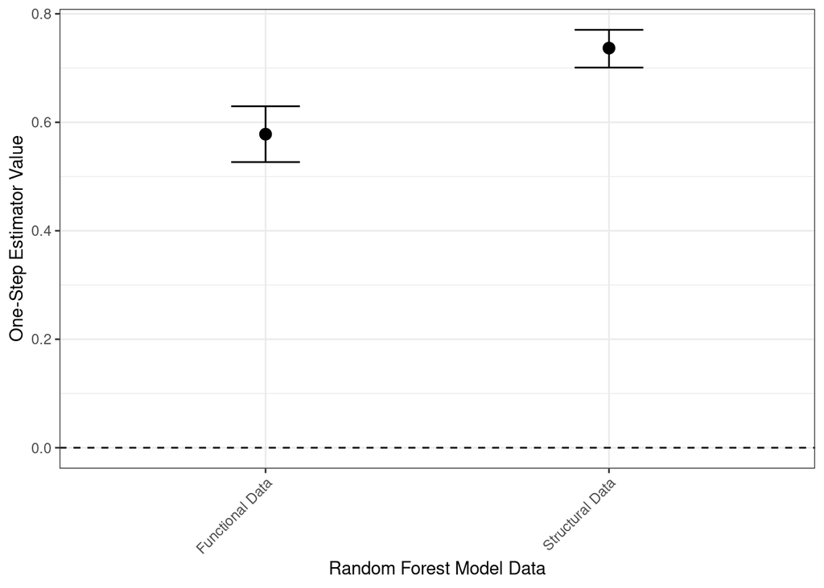

```r
# Filtering to only the estimates for the eTIV and nWBV estimates
toPlot <- results$est_summary %>% filter((metric == "Structural Data" | metric == "Functional Data") & scale == "r")
toPlot_Diff <- results$est_summary %>% filter(metric == "Difference")

# Plotting one-step results
ggplot(toPlot, aes(x = metric, y = est)) +
  geom_point(position = position_dodge(width = 0.5), size = 3) +
  geom_errorbar(aes(ymin = LB, ymax = UB),
                width = 0.2,
                position = position_dodge(width = 0.5)) +
  theme_bw() +
  theme(axis.text.x = element_text(angle = 45, hjust=1)) +
  geom_hline(yintercept = 0, linetype = "dashed", color = "black")  +
  labs(x = "Random Forest Model Data", y = "One-Step Estimator Value")
```

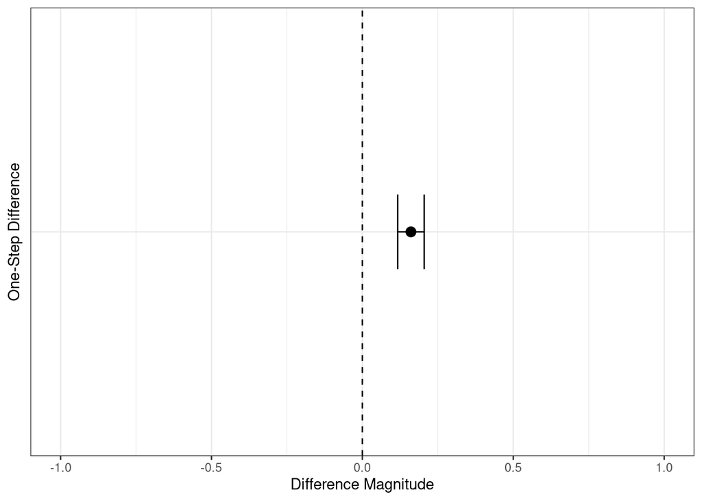

```r
# Plotting one-step difference results
ggplot(toPlot_Diff, aes(x = metric, y = est)) +
  geom_point(position = position_dodge(width = 0.5), size = 3) +
  geom_errorbar(aes(ymin = LB, ymax = UB),
                width = 0.2,
                position = position_dodge(width = 0.5)) +
  theme_bw() +
  theme(axis.ticks.y = element_blank(), axis.text.y = element_blank()) +
  coord_flip() +
  geom_hline(yintercept = 0, linetype = "dashed", color = "black")  +
  ylim(-1,1) +
  labs(x = "One-Step Difference", y = "Difference Magnitude")
```